# ProjectB - R U Kidding? - Most popular and most likely to say yes individuals

Team 9: R U Kidding? Amy Maloche, Jake Fry, Shireen Zhou, Justin Mao, Delphine Ruaro

4/13/2017

> Now that we have a better understanding of the data (Part1.Rmd) and have identified an opportunity in positioning the platform as mainly for people that share a common passion (e.g. entrepreneurship), we will try and see if one specific type of person got more matches. We will then look at whether one specific type of person said “yes” more often.

## Top 100 People with the most matches

We will identify the top 100 individuals that got the highest number of matches, and see if the majority can be identified as part of one main group.

### Percentage of matches amongst race groups

We first looked at the percentage of matches amongst race groups.

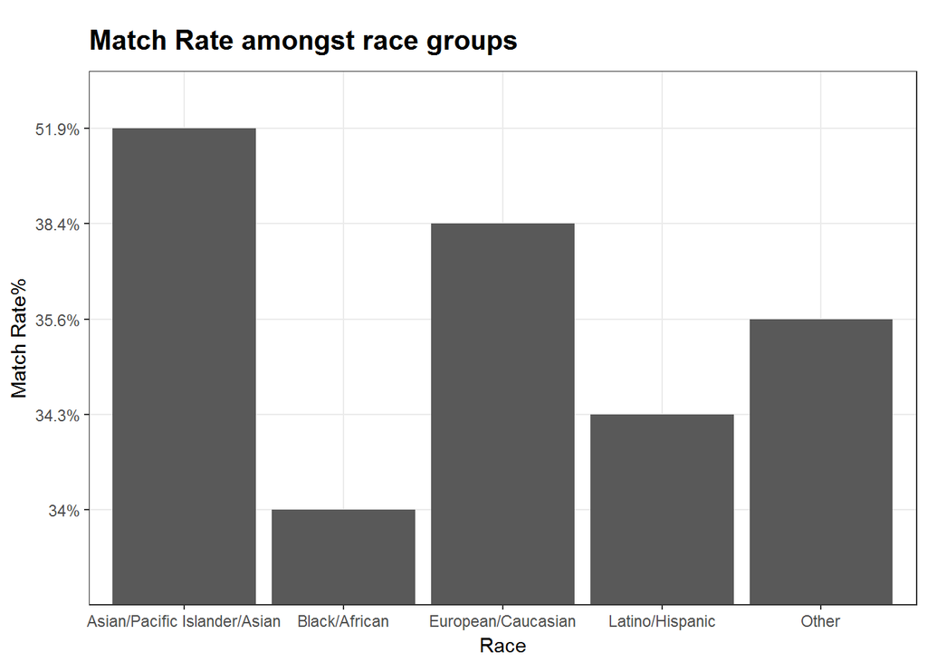

> Asians/Pacific Islanders/Asian-Americans seem to be the most attractive, with a match rate of around 52%, followed by European/Caucasian American with a rate of 38%. OKMatch.com should make sure to attract individuals from those race groups.

### Field of study

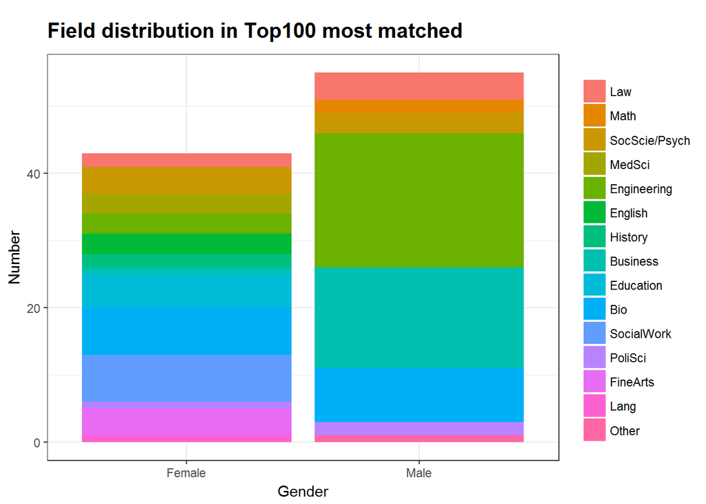

> Among the top 100 people with the most matches, female had a pretty diverse distribution of career fields. However, males studying in Engineering and Business clearly made up for the majority of the top most matched men. **Recommendation:** we would suggest targeting males in those fields of study.

### Aspirational career

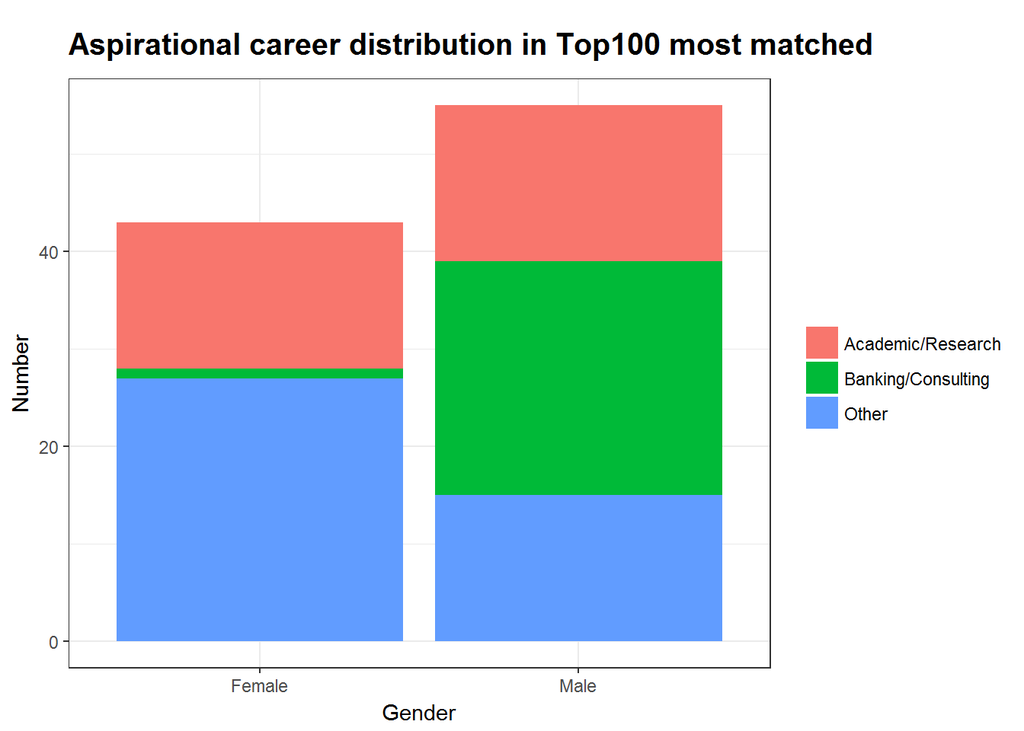

### Age

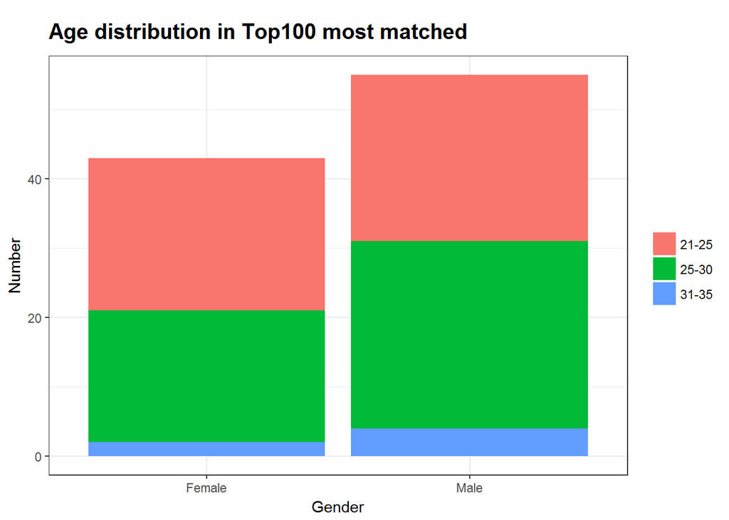

> Among the top 100 people with the most matches, both females and males were mostly in their 20s, although males had a larger median.

## Top 100 most likely to say yes

We will now look at the top 100 individuals that said “yes” the most often.

### Percentage of “yes” amongst race groups

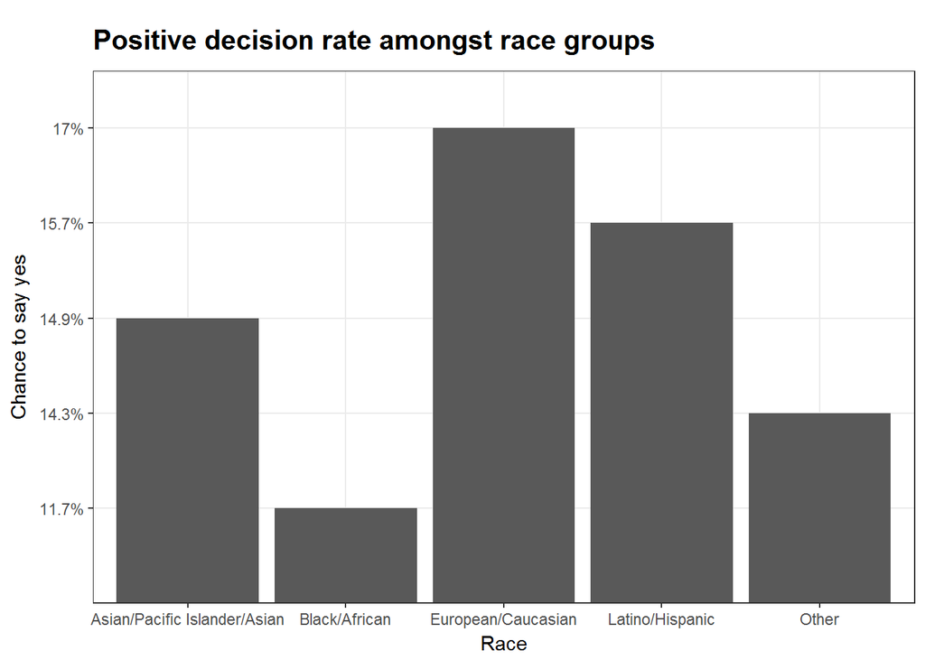

> We can see that decision rates vary less in terms of demographics. European/Caucasian Americans and Latino/Hispanic Americans were most likely to say yes. We can notice that this does not correspond to the people being the most matched.

### Field of study

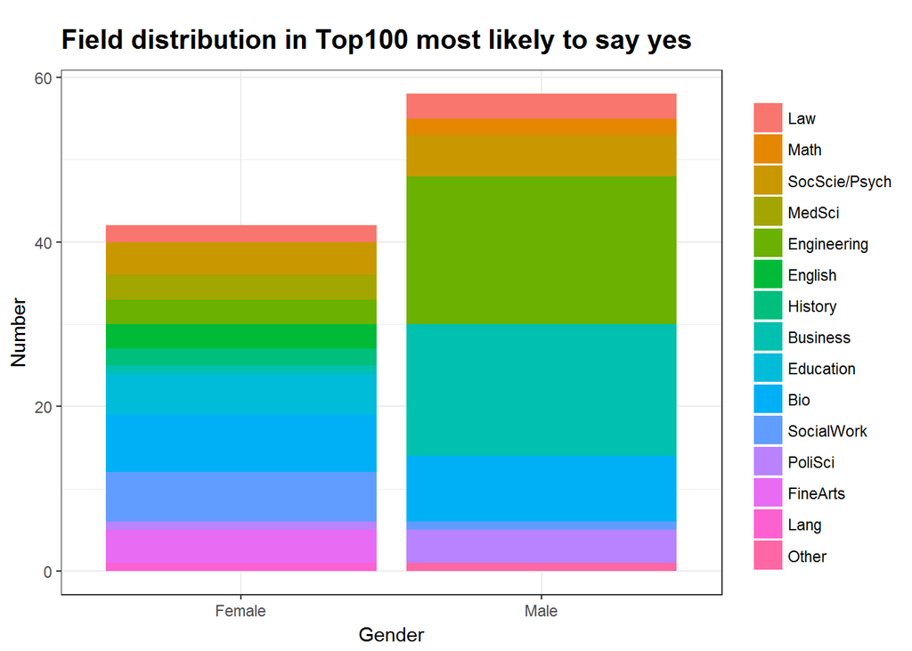

> When looking at field of study, results are pretty similar to the top 100 most matched individuals. This suggests that males in Engineering and Business are both likely to match and to be matched.

### Aspirational career

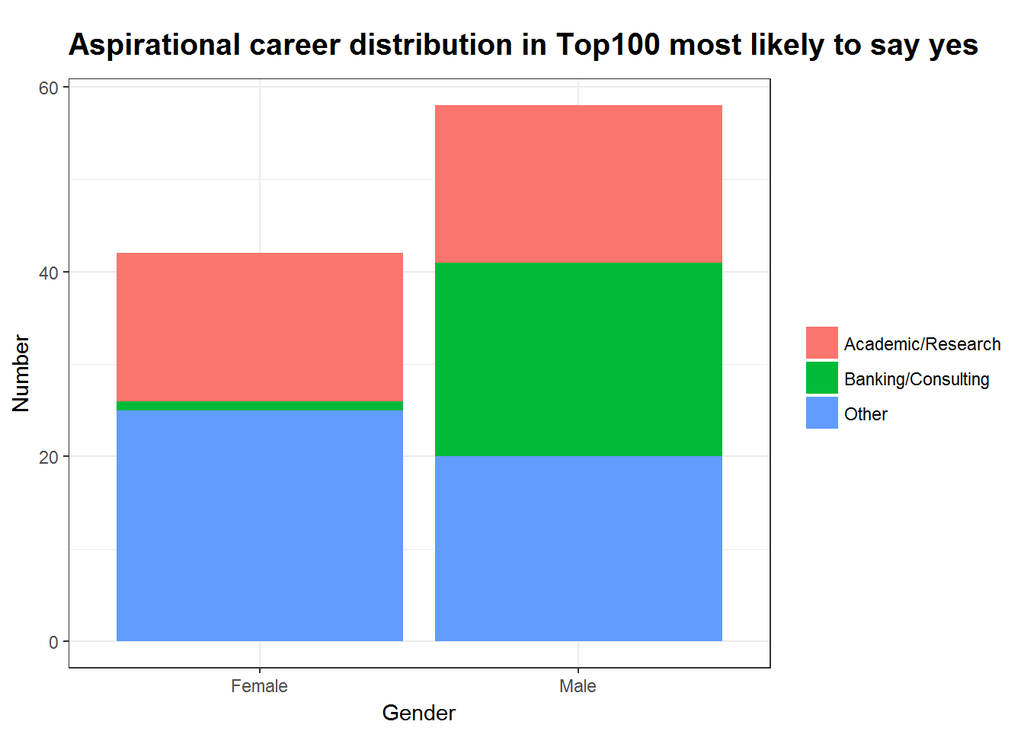

> Aspirational career’s distribution is similar between popular people and people most likely to say yes. However, males who are likely to say yes tend to be represent the “other” field more, while most popular males are more centralized in Banking and Consulting.

### Age

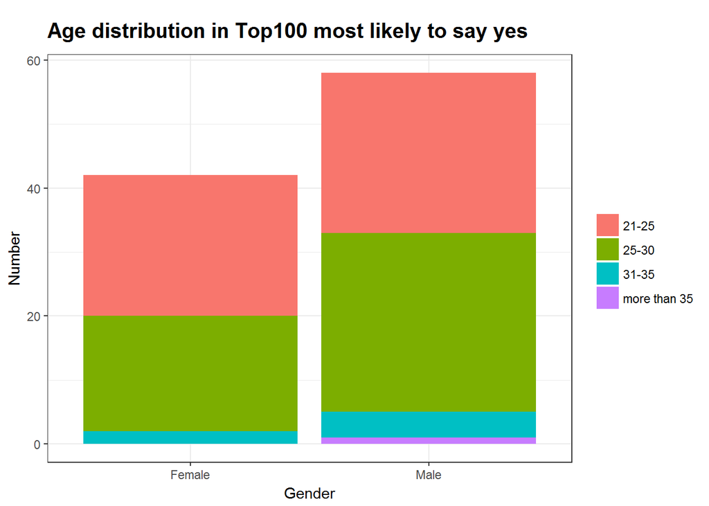

> Age distribution is also similar between popular people and people most likely to say yes, although some of the males most likely to say yes were more than 35, a population that was not part of the most popular males.

## Conclusion

> Overall, we identified that males studying in Engineering and Business were very popular. Asians/Pacific Islanders/Asian-Americans also seemed to be very popular, and proportionally attracted more matches than the other race groups. These findings must however be taken into perspective as those groups were more greatly represented in the dataset.